# scRNAseq Interstitial cells : What happens over time?

Marion Hardy

2024-02-27

# Introduction

Data from our collaborator Panagiotis rds file for a SingleCellExperiment object containing the single cell data for **the interstitial cells** of *Hydra Vulgaris* during multiples stages of regeneration after bisection:

https://www.dropbox.com/scl/fi/dg76sigjnj5u6qr06xk79/sce_interstitial_Juliano.rds?rlkey=f0y3lqt0wdcwq652zisnrpf9t&dl=0

BUT they mapped it to *Hydra Magnipapillata (102)* “Drop-seq reads from 15 libraries generated for Hydra vulgaris strain AEP were mapped to the 2.0 genome assembly of closely related Hydra vulgaris strain 102 (available at https://research.nhgri.nih.gov/hydra/) and processed using the Hydra 2.0 gene models. Strain Hydra vulgaris 102 was formerly referred to as Hydra magnipapillata.”

The coldata of the object contain cell annotation including

- quality metrics: nFeature nCount (not MT percentage interestingly)
- batch info: either 2869 (3162 barcodes), 3113 (10352 barcodes), 3271 (13279 barcodes), 3357 (3875 barcodes)
- originating experiments (head or foot regeneration)
- experimental time points
- pseudo-axis assignment (vals.axis ranging from 0-1, increasing in the foot-tentacle direction)
- mitotic and apoptotic signatures indices from 0 to 1

The rowdata contains gene annotation, using Entrez-gene identifiers. I have also noticed that in the sce objects there’s

- PCA, tSNE and UMAP coordinates for reduced dimensions + corrected for batch values
- assay metafeatures hold gene_id, product, gene, is.rib.prot.gene (T/F), HypoMarkers (T/F), ccyle (T/F), apopt (T/F) etc

I converted the sce objects 6.6gb into a seurat object 2.2 gb and checked that all cited parameters could be found in it.

# Summary of talks with Hannah and Celina

- REG_FOOT = It’s a head that is regenerating a foot (counterintuitive)
- Clusters have been attributed with confidence except 10 which is likely doublets but should be explored further
- Cluster 5 are probably glands but I haven’t found a characterized marker I could use with the Hydra atlas
- It looks like the foot neurons (ec5,ec3A) were not captured in this dataset :(
- Explore their pseudoaxis parameter maybe?? see the preprint (https://www.biorxiv.org/content/10.1101/2024.02.08.579449v1.full.pdf)

# Data loading and upate on the project

In this report we’re gonna plot transcription factors of interest over the different timepoints. I also wanted to add cell population counts over time. Maybe I could learn to plot gene expression over time too?= Anyway, we’re exploring gene expression programs and cell populations over time.

## Subsetting by head/foot and timepoint

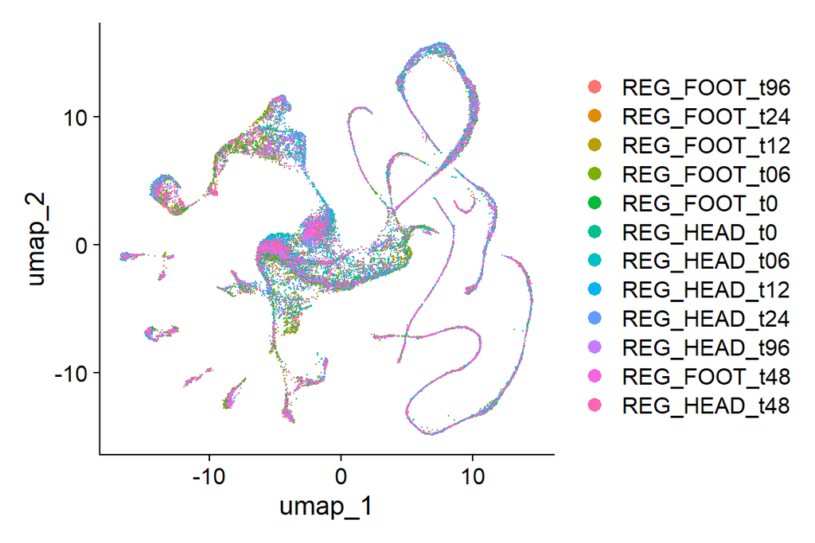

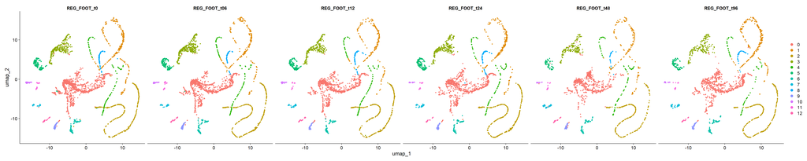

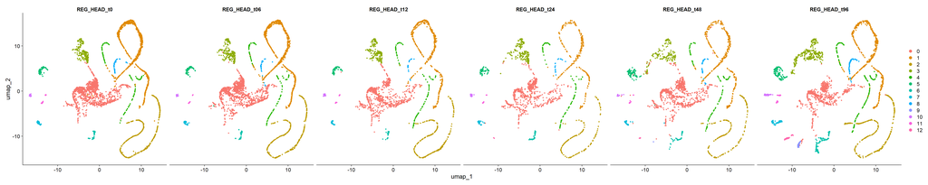

## Cluster attribution

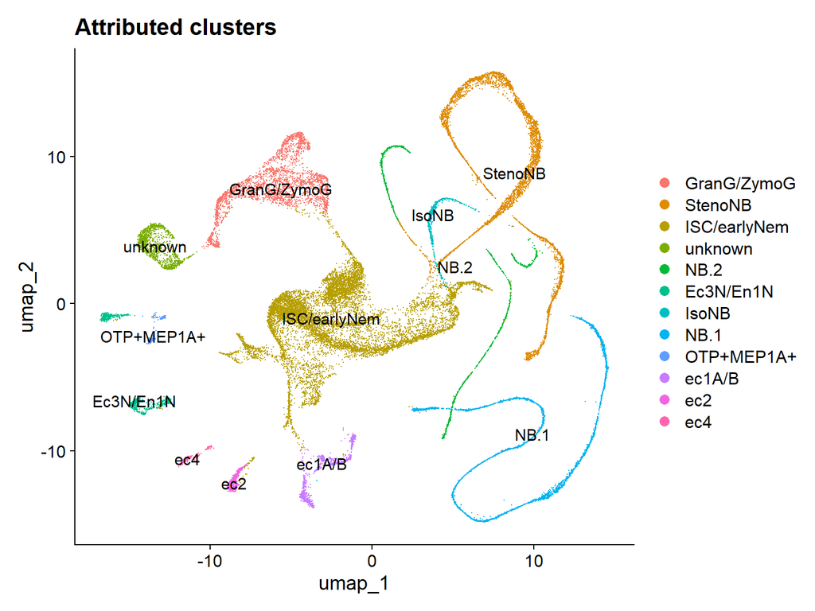

## Transcription marker expression

Celina provided me with a list of markers of interest that I tried to find in the 102 genome.

```
##     Symbol Symbol_updated
## 1     XBP1           <NA>
## 2     ERFL           <NA>
## 3    ETV3L           <NA>
## 4      ERF           <NA>
## 5     ETV3           <NA>
## 6    c-Jun            jun
## 7  c-JUNK1        c-JUNK1
## 8    CCAAT          CCAAT
## 9  CREBP-H        CREBP-H
## 10  CREBP3         CREBP3
## 11    ATF1  possibly-ATF1
## 12   ATF6b          ATF6b
## 13    ATF3           ATF3
## 14  LZTFL1         LZTFL1
```

[output cut: 18 more lines]

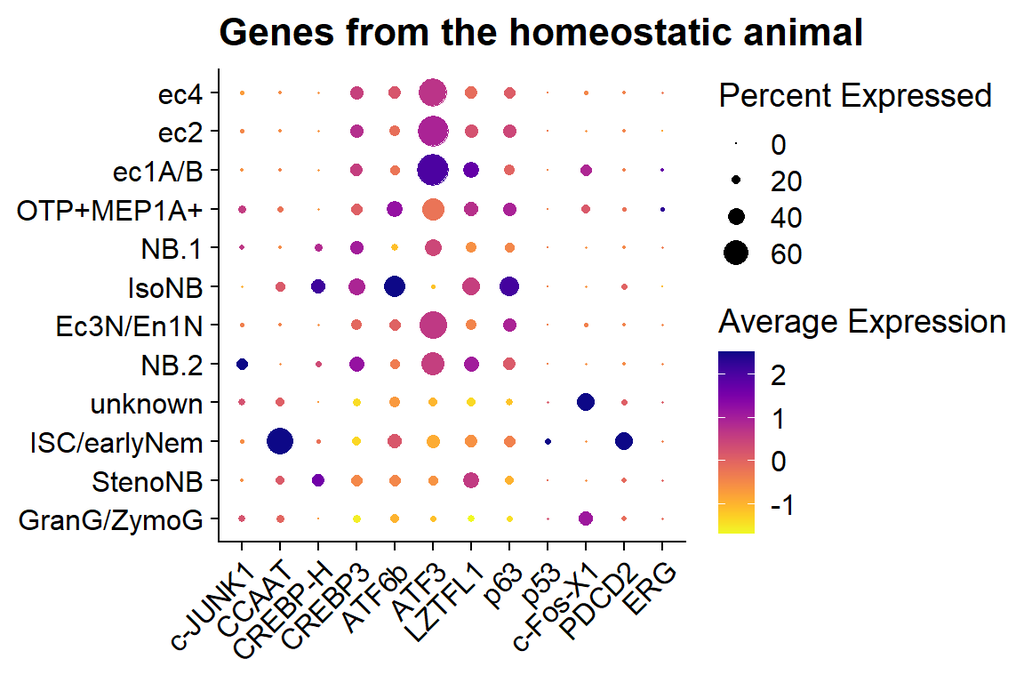

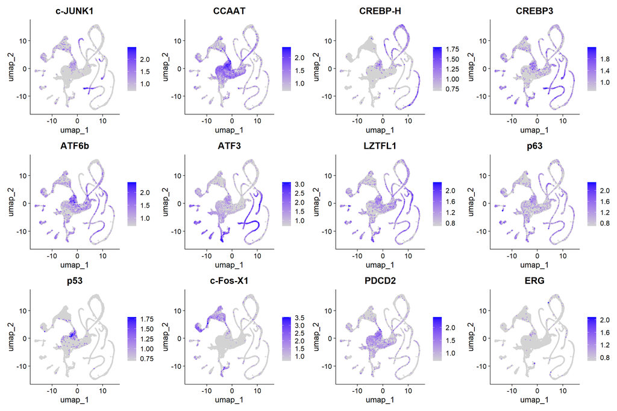

# Only neurons

I am scaling down to see if I can get genes with interesting patterns between stem cells -> neurons

I am trying to see regulatory genes appear with the appearing head neuron cluster…

## Reprocessing for re-clustering

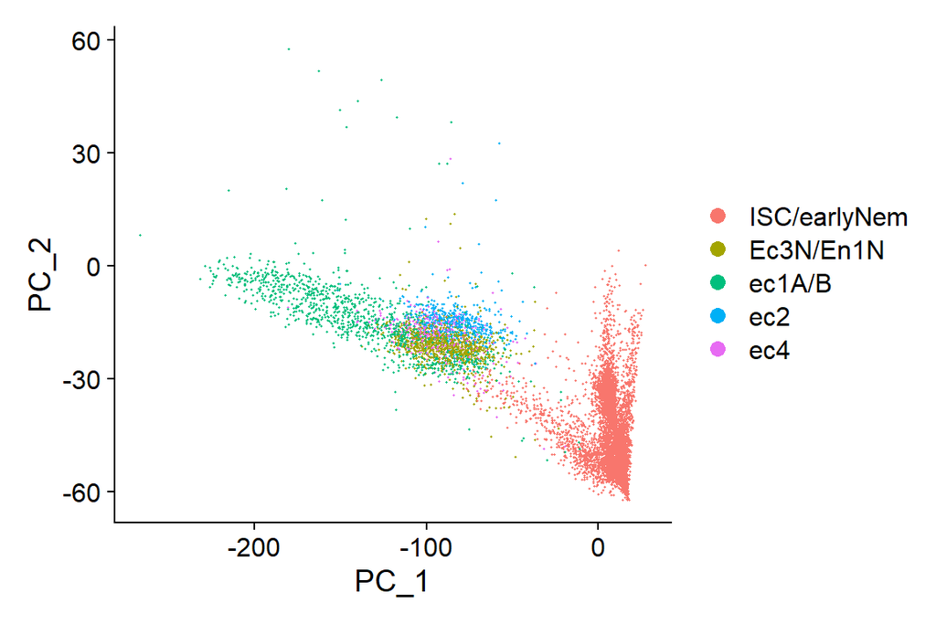

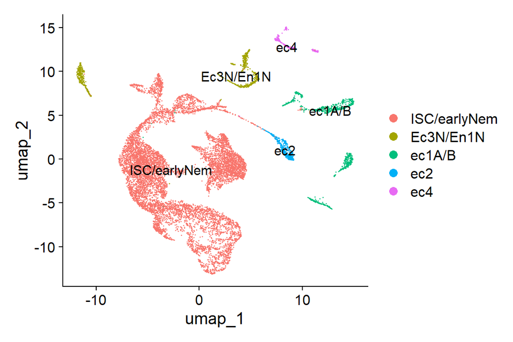

```
## Modularity Optimizer version 1.3.0 by Ludo Waltman and Nees Jan van Eck
##
## Number of nodes: 13784
## Number of edges: 445408
##
## Running Louvain algorithm...
## Maximum modularity in 10 random starts: 0.9870
## Number of communities: 9
## Elapsed time: 1 seconds
```

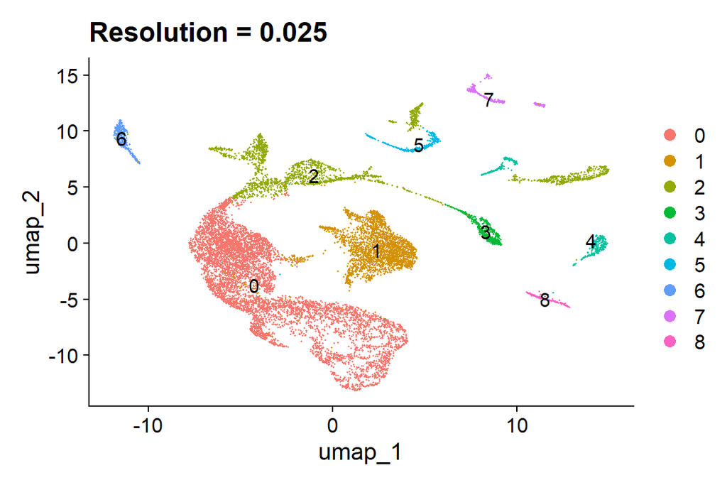

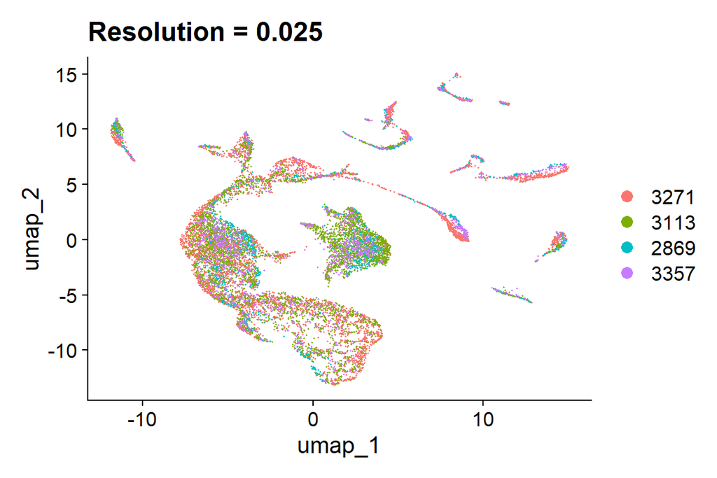

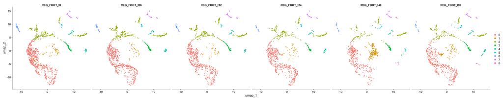

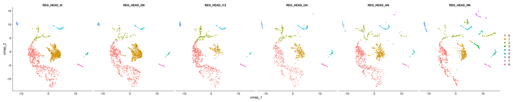

## Finding markers per clusters

```
##           X p_val avg_diff pct.1 pct.2 p_val_adj cluster      gene
## 1      TYN1     0 3.729266 0.998 0.456         0       0      TYN1
## 2 100204143     0 2.893600 0.983 0.442         0       0 100204143
## 3 100202546     0 2.699567 0.977 0.381         0       0 100202546
## 4     ANO39     0 2.684201 0.923 0.468         0       0     ANO39
## 5 100198330     0 2.546972 0.927 0.404         0       0 100198330
## 6 100203239     0 2.496339 0.951 0.314         0       0 100203239
```

I am going to scale down, these are too many unidentified genes. Let’s keep:

```r
target <- c("NSP4","midasin","mini-COL8","SP-D-like","FH20-X3","CAII",
            "CELA3B","zinc-carboxypeptidase","ANO39","TYN1","H2A.2.2","nas2-X2",
            "Lwamide-X1","DMRT1","TUBA4A-X1","HTRA3","polRF-X1","ec3A","ec3B",
            "nop58-X1","OTP","MEP1A","rhammosyl-O-methyltransferase","hywnt3",
            "PPOD1","ks1","hyAlx","ELAV2","POU4","MUC2", "ec3", "grm1","myc",
            "myc1","wnt3","ec2","ec1B","ec4","ec1A","en1","en1_NDF1_DANRE",
            "101235516","100204363","100200547","100204143","100210809",
            "100208683","100203070","ec5","en1","en2A","en2B")
```

### Foot neurons clusters per cell type

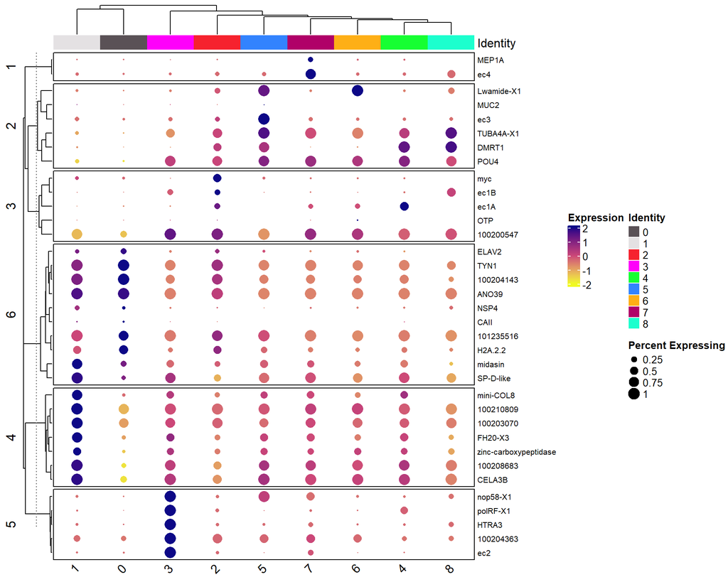

### Head neurons clusters per cell type

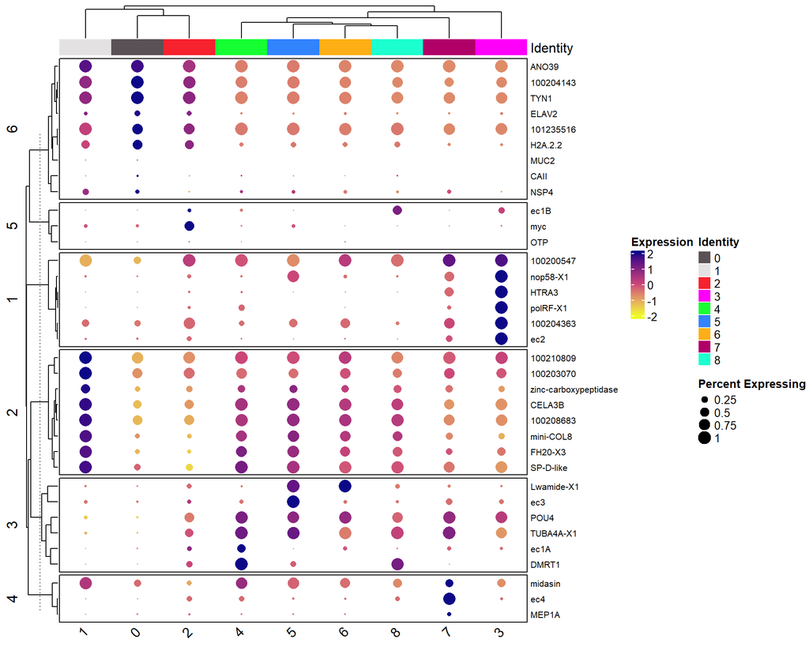

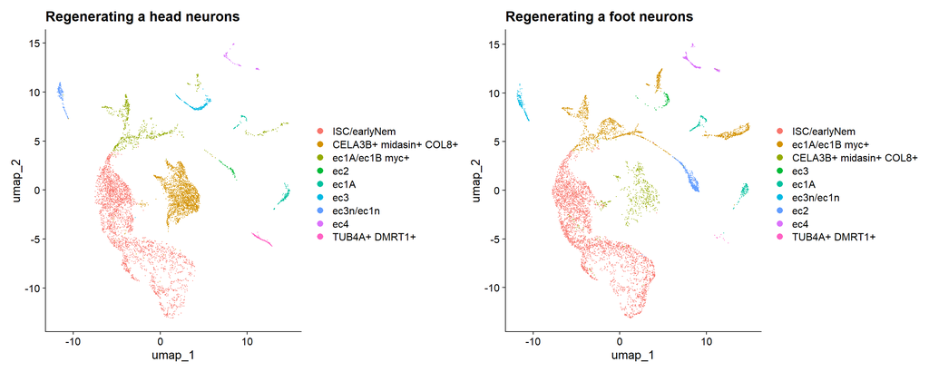

### Foot neurons clusters per timepoint

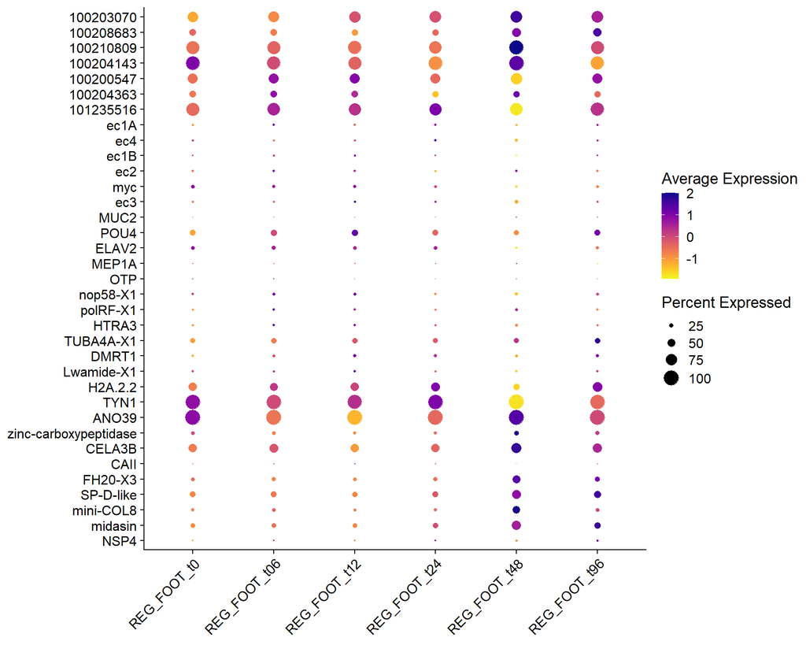

### Head neurons clusters per timepoint

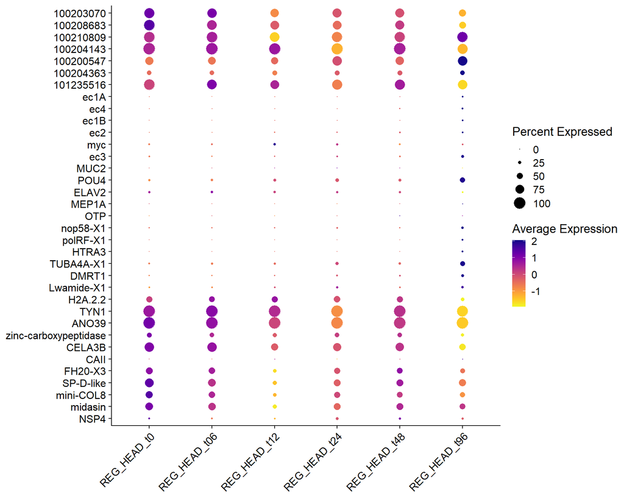

Please note the behavior of - 100203070 and others which are OPPOSITE in regenerating a head vs a foot over time

### Feature plots

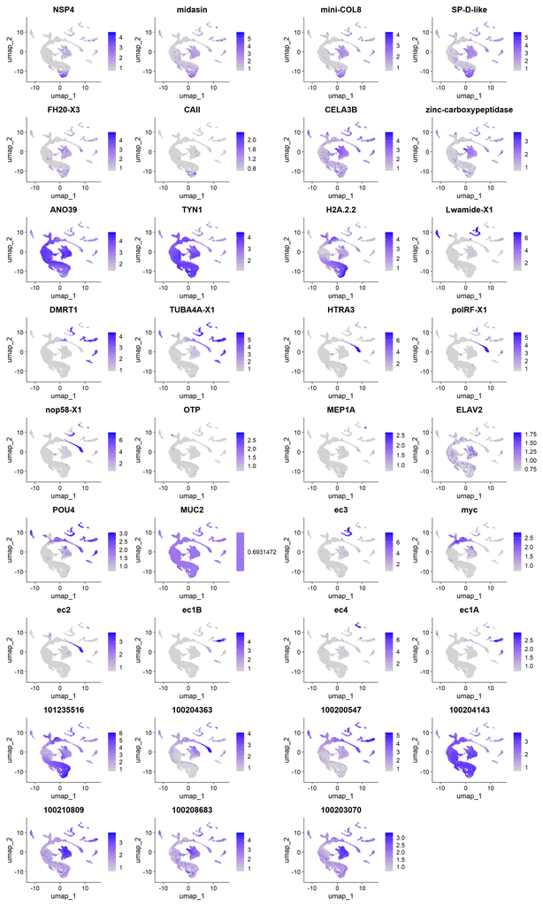

## Cell population evolution over time

### Regenerating a head

|  | REG_HEAD_t0 | REG_HEAD_t06 | REG_HEAD_t12 | REG_HEAD_t24 | REG_HEAD_t48 | REG_HEAD_t96 |
| --- | --- | --- | --- | --- | --- | --- |
| ISC/earlyNem | 680 | 588 | 546 | 279 | 465 | 462 |
| CELA3B+ midasin+ COL8+ | 688 | 572 | 135 | 217 | 289 | 252 |
| ec1A/ec1B myc+ | 79 | 81 | 153 | 109 | 111 | 183 |
| ec2 | 0 | 0 | 0 | 0 | 1 | 57 |
| ec1A | 28 | 21 | 12 | 23 | 24 | 81 |
| ec3 | 49 | 37 | 42 | 51 | 46 | 60 |
| ec3n/ec1n | 27 | 27 | 29 | 27 | 18 | 63 |
| ec4 | 0 | 0 | 0 | 2 | 6 | 71 |
| TUB4A+ DMRT1+ | 37 | 32 | 34 | 41 | 22 | 31 |
| Sum | 1588 | 1358 | 951 | 749 | 982 | 1260 |

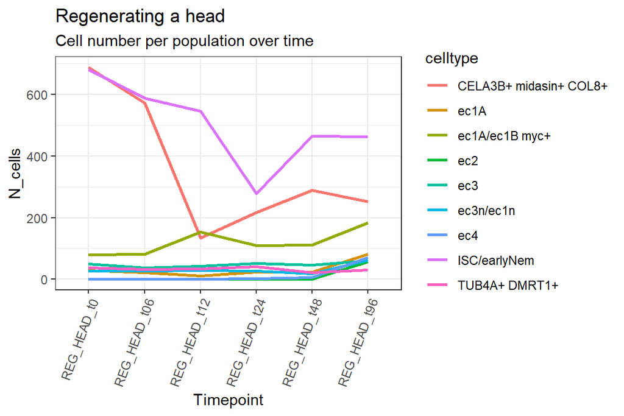

### Regenerating a foot

|  | REG_FOOT_t0 | REG_FOOT_t06 | REG_FOOT_t12 | REG_FOOT_t24 | REG_FOOT_t48 | REG_FOOT_t96 |
| --- | --- | --- | --- | --- | --- | --- |
| CELA3B+ midasin+ COL8+ | 70 | 41 | 42 | 52 | 211 | 93 |
| ec1A | 52 | 55 | 41 | 50 | 31 | 49 |
| ec1A/ec1B myc+ | 303 | 323 | 285 | 245 | 162 | 199 |
| ec2 | 81 | 104 | 76 | 63 | 86 | 51 |
| ec3 | 17 | 13 | 16 | 15 | 13 | 16 |
| ec3n/ec1n | 47 | 40 | 33 | 21 | 18 | 24 |
| ec4 | 48 | 48 | 45 | 43 | 42 | 32 |
| ISC/earlyNem | 774 | 707 | 602 | 617 | 400 | 490 |
| TUB4A+ DMRT1+ | 0 | 0 | 0 | 0 | 4 | 6 |
| Sum | 1392 | 1331 | 1140 | 1106 | 967 | 960 |

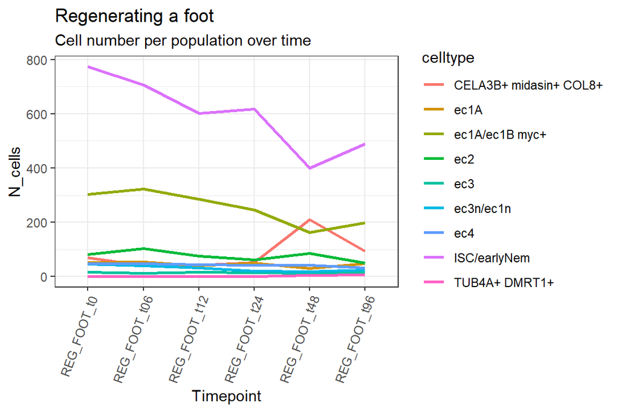

## Transcription factors

### Feature plot

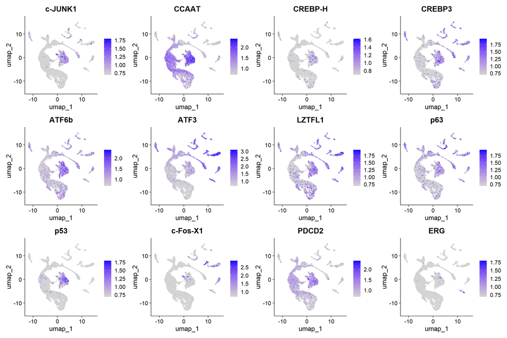

### Clustered dotplot

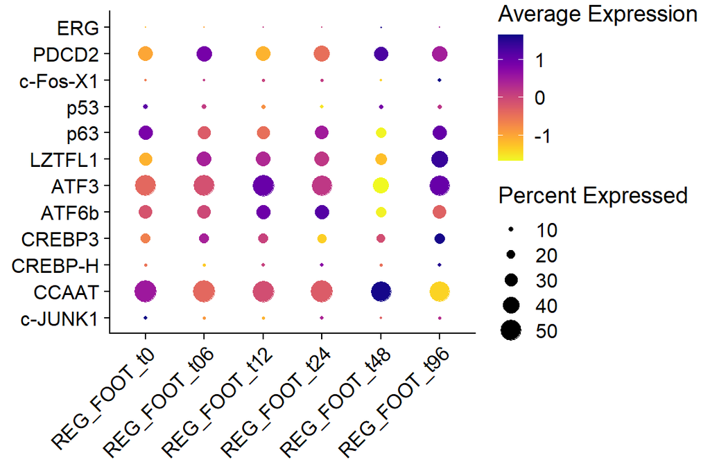

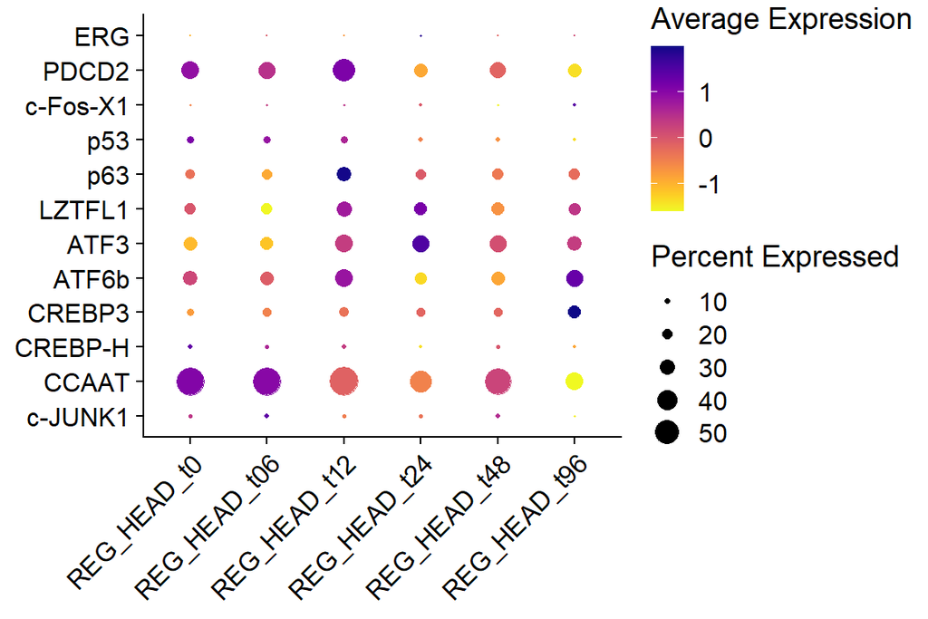

I feel like I really want to do this per neuron subcluster…

## Neurons subclusters

### Wtf is up with the CELA3B+ COL8+ midasin+ stem cell-like cluster?